[interactive chart not shown]

# Decision Tree Classifier (Income Prediction)

#### **Instructor:** [Vijay Gurbani (Chief Data Scientist at Vail Systems, Inc)](https://youtu.be/8oDjrAknr4o?t=11)

#### **Project Summary**

- Analyzed a dataset to predict whether individuals earn more or less than $50K based on demographic and financial features.
- Cleaned and prepared the dataset, handling missing values and feature selection.
- Constructed a decision tree classifier to predict income levels and evaluated model performance with accuracy, sensitivity, and specificity metrics.
- Compared the performance of balanced and imbalanced datasets to identify the most effective approach.

#### **About the Dataset**

This dataset, extracted from the 1994 Census Bureau database by Ronny Kohavi and Barry Becker, contains 48,221 records and 15 attributes. It includes demographic and financial data to predict whether an individual earns more than $50K annually. Key features include age, education, occupation, and capital gain, with the goal of identifying patterns related to income levels.

#### **Conclusions**

This project demonstrates my ability to build, evaluate, and optimize machine learning models using decision trees. It underscores the importance of data preprocessing and balancing techniques to improve model accuracy. The insights gained from comparing different models showcase the complexities of trade-offs in predictive modeling.

Income Prediction Classifier

- Return to projects

Sections

- Data Cleaning & Preparation
- Model 1 Analysis and Development
- Model 2 Analysis and Development
- Key Findings & Conclusion

### Data Cleaning and Preparation

I started by loading and cleaning the 'adult-test.csv' and 'adult-train.csv' datasets. This involved removing rows with missing values across various attributes such as age, education, and income. Ensuring the data is clean is a crucial step in building reliable models, as it helps prevent issues that could arise from incomplete data. After cleaning, I verified the dimensions of both datasets to confirm the number of observations and features.

```r
setwd("C:/Users/directory-removed")

working_directory <- getwd()
setwd(working_directory)

test <- read.csv('adult-test.csv', header = TRUE, sep = ",")
train <- read.csv('adult-train.csv', header = TRUE, sep = ",")


test <- test[test$age != '?' &
             test$workclass != '?' &
             test$fnlwgt != '?' &
             test$education != '?' &
             test$education_num != '?' &
             test$marital_status != '?' &
             test$occupation != '?' &
             test$relationship != '?' &
             test$race != '?' &
             test$sex != '?' &
             test$capital_gain != '?' &
             test$capital_loss != '?' &
             test$hours_per_week != '?' &
             test$native_country != '?' &
             test$income != '?', ]

train <- train[train$age != '?' &
             train$workclass != '?' &
             train$fnlwgt != '?' &
             train$education != '?' &
             train$education_num != '?' &
             train$marital_status != '?' &
             train$occupation != '?' &
             train$relationship != '?' &
             train$race != '?' &
             train$sex != '?' &
             train$capital_gain != '?' &
             train$capital_loss != '?' &
             train$hours_per_week != '?' &
             train$native_country != '?' &
             train$income != '?', ]


print(dim(test))
```

```
[1] 15060    15
```

```r
print(dim(train))
```

```
[1] 30161    15
```

### Model 1 Analysis and Development

Next, I built a decision tree classifier using the 'rpart' library in R. The model was trained on the cleaned training dataset, with income as the target variable.

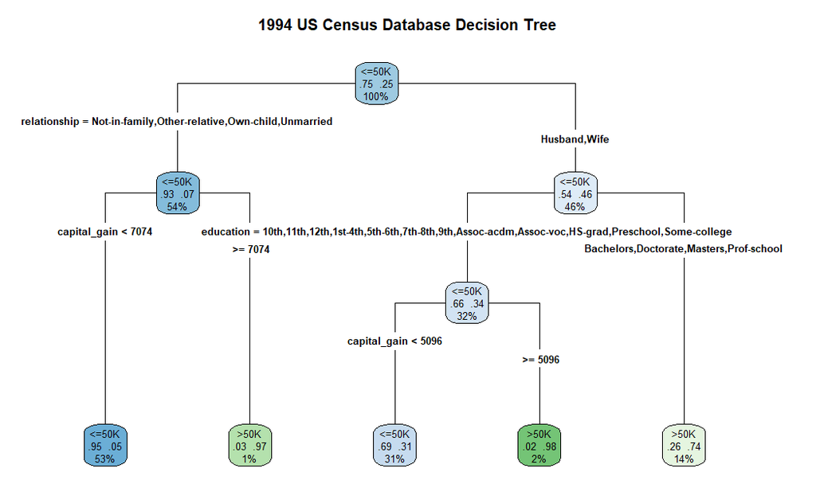

```r
set.seed(1122)
model <- rpart(income ~ . , data = train, method = "class")

rpart.plot(model, extra=104, fallen.leaves=T, type=4, main="1994 US Census Database Decision Tree")
```

#### Key Predictors and Initial Split

**Q:** What are the top three predictors in your decision tree model for income classification?  
**A:** The top three predictors identified by the decision tree model are education, relationship status, and capital gain.

**Q:** What was the first attribute split in the decision tree, and what was the predicted class?  
**A:** The first split in the decision tree was made based on the relationship attribute. The predicted class for the first node was individuals earning <=50K.

**Q:** What was the distribution of observations in the first node after the initial split?  
**A:** The distribution of observations at the first node was 75% for individuals earning <=50K and 25% for individuals earning >50K.

#### Summary

In my decision tree model, the top three predictors influencing income classification were education, relationship status, and capital gain. The first split in the decision tree occurred on the relationship attribute, with the predicted class for the first node being individuals earning <=50K. At this point, the distribution of observations was 75% for the <=50K class and 25% for the >50K class, showing that relationship status plays a significant role in the model’s initial prediction.

#### Model Evaluation: Confusion Matrix and Metrics

To evaluate the model, I used a confusion matrix to calculate important performance metrics, including accuracy, sensitivity, and specificity. The accuracy of the model was 83.9%, with a high sensitivity of 94.82% and a specificity of 50.35%. These metrics give insight into how well the model can correctly classify individuals who earn less than $50K (high sensitivity) but show the challenge of correctly identifying individuals earning more than $50K (lower specificity).

```r
pred <- predict(model, test, type="class")
print(confusionMatrix(as.factor(pred), as.factor(test[, 15])))
```

```
Confusion Matrix and Statistics

          Reference
Prediction <=50K  >50K
     <=50K 10772  1837
     >50K    588  1863

               Accuracy : 0.839
                 95% CI : (0.833, 0.8448)
    No Information Rate : 0.7543
    P-Value [Acc > NIR] : < 2.2e-16

                  Kappa : 0.5098

 Mcnemar's Test P-Value : < 2.2e-16

            Sensitivity : 0.9482
            Specificity : 0.5035
         Pos Pred Value : 0.8543
         Neg Pred Value : 0.7601
             Prevalence : 0.7543
         Detection Rate : 0.7153
   Detection Prevalence : 0.8373
      Balanced Accuracy : 0.7259

       'Positive' Class : <=50K
```

```r
TP <- 10772
TN <- 1863
FN <- 1837
FP <- 588

sensitivity <- TP / (TP + FN)
specificity <- TN / (TN + FP)
balanced_accuracy <- (sensitivity + specificity) / 2
balanced_error_rate <- 1 - balanced_accuracy

cat(paste(" Sensitivity:", round(sensitivity, 2), "\n"),
    paste("Specificity:", round(specificity, 2), "\n"),
    paste("Balanced Accuracy:", round(balanced_accuracy, 2), "\n"),
    paste("Balanced Error Rate:", round(balanced_error_rate, 2)))
```

```
 Sensitivity: 0.85
 Specificity: 0.76
 Balanced Accuracy: 0.81
 Balanced Error Rate: 0.19
```

#### ROC Curve and Area Under the Curve (AUC)

I further evaluated the model by plotting the ROC curve and calculating the area under the curve (AUC), which came out to 0.84. The AUC is a valuable metric because it measures the ability of the classifier to distinguish between classes. A higher AUC indicates a better-performing model, with 0.84 representing a strong classifier for this dataset.

```r
library(ROCR)
predicted_ROC <- prediction(predict(model, type = "prob")[, 2], train$income)

# plot ROC curve
roc_curve <- performance(predicted_ROC, "tpr", "fpr")
plot(roc_curve, col="blue", main="ROC Curve", lwd = 2)

# diagonal line
abline(a = 0, b = 1, lwd = 2, col = "red", lty = 2)
```

```r
# perfect classifier line
lines(c(0, 0, 1), c(0, 1, 1), lwd = 2, col = "purple")

legend("bottomright", legend = c("Random Classifier", "Perfect Classifier", "Current Classifier"),
       lty = c(1, 1, 1), lwd = 2, col = c("red", "purple", "blue"))
```

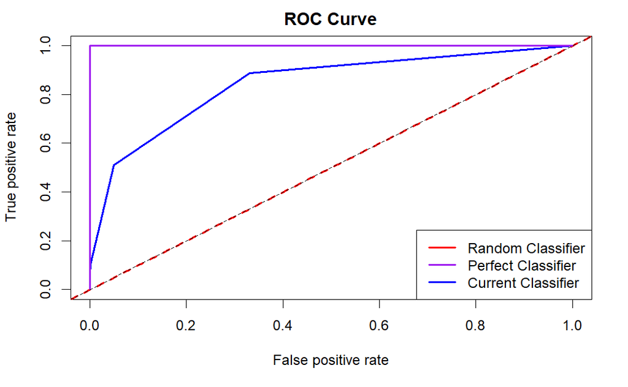

```r
area_under_the_curve <- performance(predicted_ROC, measure = "auc")
area_under_the_curve <- area_under_the_curve@y.values[[1]]
abline(0, 1, lty = 2)
```

```r
cat("Area Under the Curve: ", area_under_the_curve, "\n")
```

```
Area Under the Curve:  0.8430714
```

#### Cross-Validation and Tree Pruning

I used cross-validation to determine the optimal size of the decision tree. The complexity parameter (CP) table showed that the tree at size 4 had the lowest cross-validation error, indicating that pruning the tree beyond this point would not improve performance. By stopping at the optimal size, I ensured that the model avoided overfitting, while still maintaining good accuracy.

```r
printcp(model)
```

```
Classification tree:
rpart(formula = income ~ ., data = train, method = "class")

Variables actually used in tree construction:
[1] capital_gain education    relationship

Root node error: 7508/30161 = 0.24893

n= 30161

        CP nsplit rel error  xerror      xstd
1 0.129995      0   1.00000 1.00000 0.0100018
2 0.064198      2   0.74001 0.74001 0.0089670
3 0.037294      3   0.67581 0.67581 0.0086527
4 0.010000      4   0.63852 0.63852 0.0084574
```

#### Class Imbalance and Balancing the Dataset

```r
set.seed(1122)

less_or_equal_to_50 <- nrow(train[train$income == '<=50K', ])
greater_than_50 <- nrow(train[train$income == '>50K', ])
cat(" Less or equal to 50K: ", less_or_equal_to_50,"\n",
    "Greater than 50K: ", greater_than_50, "\n")
```

```
 Less or equal to 50K:  22653
 Greater than 50K:  7508
```

```r
train_less_or_equal_to_50 <- train[train$income == '<=50K', ]
under_sample_train_less_or_equal_to_50 <- train_less_or_equal_to_50[sample(nrow(train_less_or_equal_to_50), greater_than_50, replace = FALSE, prob = NULL), ]

train_greater_than_50 <- train[train$income == '>50K', ]
cat(" Less or equal to 50K: ",nrow(under_sample_train_less_or_equal_to_50),"\n",
    "Greater than 50K: ", nrow(train_greater_than_50), "\n")
```

```
 Less or equal to 50K:  7508
 Greater than 50K:  7508
```

```r
balanced_train <- rbind(under_sample_train_less_or_equal_to_50,train_greater_than_50)
```